# PML Project

# *Introduction*

Using devices such as Jawbone Up, Nike FuelBand, and Fitbit it is now possible to collect a large amount of data about personal activity relatively inexpensively. These type of devices are part of the quantified self movement - a group of enthusiasts who take measurements about themselves regularly to improve their health, to find patterns in their behavior, or because they are tech geeks. One thing that people regularly do is quantify how much of a particular activity they do, but they rarely quantify how well they do it. In this project, your goal will be to use data from accelerometers on the belt, forearm, arm, and dumbell of 6 participants. They were asked to perform barbell lifts correctly and incorrectly in 5 different ways.

*The packages included:*

```r
library(AppliedPredictiveModeling)
library(caret)
## Loading required package: lattice
## Loading required package: ggplot2
library(rattle)
## Rattle: A free graphical interface for data mining with R.
## Version 3.0.2 r169 Copyright (c) 2006-2013 Togaware Pty Ltd.
## Type 'rattle()' to shake, rattle, and roll your data.
library(rpart.plot)
## Loading required package: rpart
library(randomForest)
## randomForest 4.6-7
## Type rfNews() to see new features/changes/bug fixes.
library(corrplot)
```

*Input Data*

```r
training <- read.csv(traing_file, na.strings=c("NA",""), header=TRUE)
testing <-read.csv(test_file, na.strings=c("NA",""), header=TRUE)
```

```r
str(training)
```

```
## 'data.frame':    19622 obs. of  160 variables:
##  $ X                       : int  1 2 3 4 5 6 7 8 9 10 ...
##  $ user_name               : Factor w/ 6 levels "adelmo","carlitos",..: 2 2 2 2 2 2 2 2 2 2 ...
##  $ raw_timestamp_part_1    : int  1323084231 1323084231 1323084231 1323084232 1323084232 1323084232 1323084232 1323084232 1323084232 1323084232 ...
##  $ raw_timestamp_part_2    : int  788290 808298 820366 120339 196328 304277 368296 440390 484323 484434 ...
##  $ cvtd_timestamp          : Factor w/ 20 levels "02/12/2011 13:32",..: 9 9 9 9 9 9 9 9 9 9 ...
##  $ new_window              : Factor w/ 2 levels "no","yes": 1 1 1 1 1 1 1 1 1 1 ...
##  $ num_window              : int  11 11 11 12 12 12 12 12 12 12 ...
##  $ roll_belt               : num  1.41 1.41 1.42 1.48 1.48 1.45 1.42 1.42 1.43 1.45 ...
##  $ pitch_belt              : num  8.07 8.07 8.07 8.05 8.07 8.06 8.09 8.13 8.16 8.17 ...
##  $ yaw_belt                : num  -94.4 -94.4 -94.4 -94.4 -94.4 -94.4 -94.4 -94.4 -94.4 -94.4 ...
##  $ total_accel_belt        : int  3 3 3 3 3 3 3 3 3 3 ...
##  $ kurtosis_roll_belt      : Factor w/ 396 levels "-0.016850","-0.021024",..: NA NA NA NA NA NA NA NA NA NA ...
##  $ kurtosis_picth_belt     : Factor w/ 316 levels "-0.021887","-0.060755",..: NA NA NA NA NA NA NA NA NA NA ...
##  $ kurtosis_yaw_belt       : Factor w/ 1 level "#DIV/0!": NA NA NA NA NA NA NA NA NA NA ...
```

[output cut: 86 more lines]

*Remove NA*

```r
var <- names(training)[apply(training, 2, function(x) table(is.na(x))[1]==19622)]
training1<- training[,var]
testing1 <- testing[,var[-length(var)]]
```

```r
removeIndex <- grep("timestamp|X|user_name|new_window|num_window",names(training1))
training2 <- training1[,-c(removeIndex, length(training1))]
testing2  <- training1[,-c(removeIndex, length(training1))]

nzv <- nearZeroVar(training2, saveMetrics=TRUE)
summary(nzv)
```

```
##    freqRatio     percentUnique    zeroVar           nzv
##  Min.   : 1.00   Min.   : 0.15   Mode :logical   Mode :logical
##  1st Qu.: 1.04   1st Qu.: 1.49   FALSE:52        FALSE:52
##  Median : 1.08   Median : 3.36   NA's :0         NA's :0
##  Mean   : 6.09   Mean   : 9.05
##  3rd Qu.: 1.14   3rd Qu.: 7.97
##  Max.   :87.26   Max.   :84.21
```

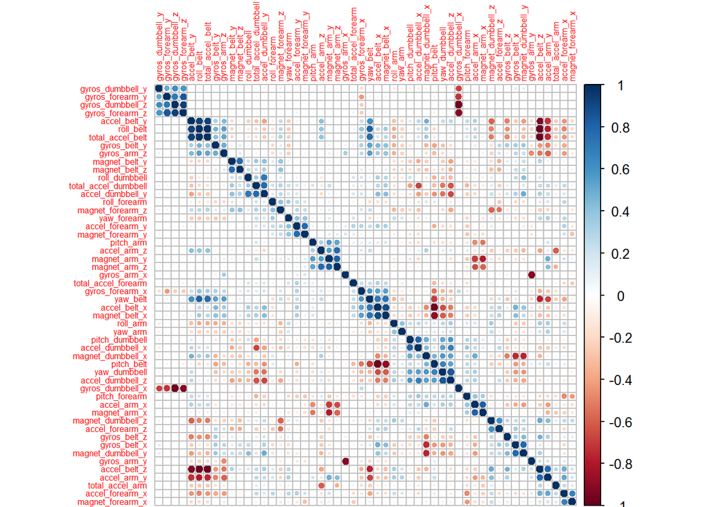

```r
correlations <- cor(training2)
corrplot(correlations,order = "hclust",tl.cex = .5)
```

*Remove High Correlation*

```r
highCorr <- findCorrelation(correlations, cutoff = .75)
predictor <- training2[, -highCorr]
filtered.testing3 <- testing2[, -highCorr]
classe<-training1$classe
trainData<-cbind(classe,predictor)
```

```r
rfModel <- randomForest(classe ~ .,data = trainData,importance = TRUE,ntrees = 10)
```

*The out of Bag error rate plot*

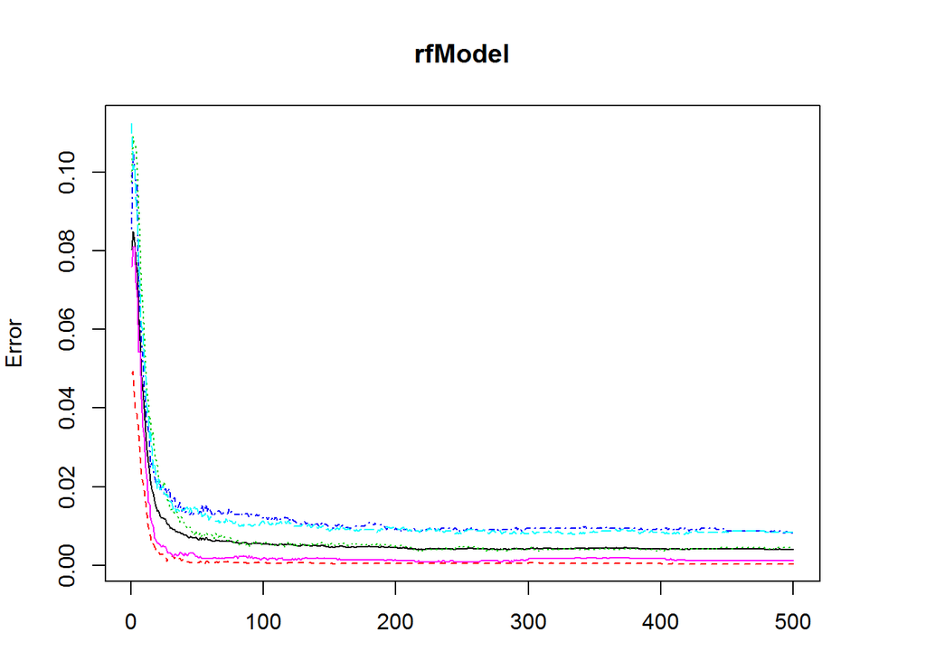

```r
par(mar=c(3,4,4,4))
plot(rfModel)
```

*Variable Importance Plot*

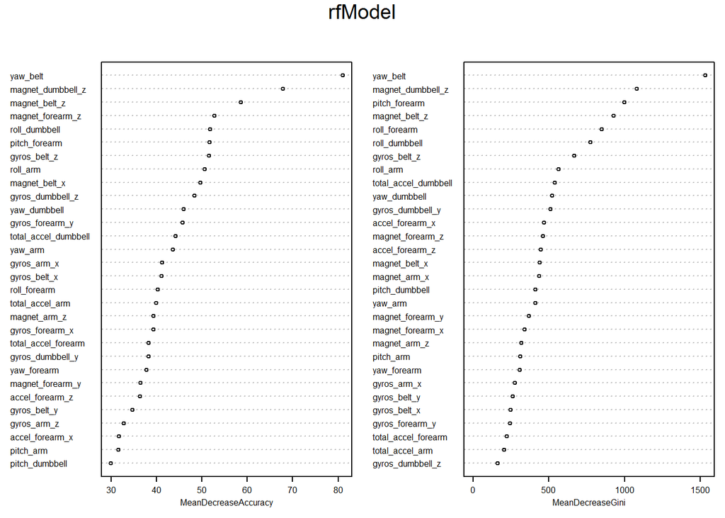

```r
varImpPlot(rfModel,cex=.5)
```

```r
pred.test<-predict(rfModel,filtered.testing3)
summary(pred.test)
```

```
##    A    B    C    D    E
## 5580 3797 3422 3216 3607
```

*Saving the Output*

```r
answers<- as.vector(pred.test)

pml_write_files = function(x){
  n = length(x)
  for(i in 1:n){
    filename = paste0("problem_id_",i,".txt")
    write.table(x[i],file=filename,quote=FALSE,row.names=FALSE,col.names=FALSE)
  }
}

pml_write_files(answers)
```